# Tarea 1

Oliver Mendez [2017-5554]

20 de septiembre 2020

Es muy habitual la utilización de software para abordar estudios cuantitativos de muchos problemas físicos, ya que la realidad es tan compleja que el tratamiento matemático de la mayoría de los sistemas ofrece unas dificultades muy considerables.

En esta ocasión, vamos a ilustrar el caso del péndulo simple. Así como lo detalla el ejercicio [(Tarea 1)](http://ac.orizondo.org/isc581/tareal01.html), es un sistema idealizado de un solo grado de libertad, un objeto de masa m, sostenido por un hilo cuya masa es despreciable que puede describirse expresando en función del tiempo su distancia angular a una dirección de referencia, tal como la vertical en un determinado punto, el considerar este sistema como idealizado se restringe las observaciones a excluir la fricción presente.

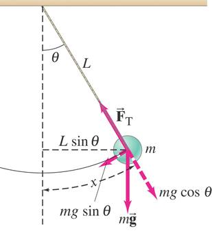

Péndulo simple

Luego de aplicar las leyes de Newton al movimiento de la masa suspendida, se llega a la siguiente ecuación diferencial de segundo orden de la que puede obtenerse la evolución en el tiempo del ángulo θ, si se conoce la elongación inicial θ0 y velocidad angular inicial ν0:

$\frac{d^{2} \theta }{dt^{2}}\, + \,\epsilon \, \sin \theta = 0$

## Estructura de la información de entrada

| Columna | Contenido |
| --- | --- |
| L(cm) | Longuitud de la cuerda (cm) obtenida. |
| P(s) | Periodos P (segundos) obtenido en la medición. |
| N(oxi) | Numero de oscilaciones obtenida en la medición. |

Cada línea posterior a la primera se corresponde con cada una de las mediciones efectuadas.

El fichero mediciones.csv, obtenido a partir del fichero mediciones.ods, es un ejemplo de la estructura anterior. Ésta puede apreciarse tecleando en la consola de R el siguiente comando cuyo resultado se muestra:

```r
writeLines(readLines(con = "mediciones.csv"), sep = "\n")
```

```
L(cm),P(s),N(oxi)
2.335,15.33,5
```

### Procedimento

Para realizar las pruebas, se utilizo un entorno lo mas realista posible para responder a este experimento, por lo que las pruebas fueron apoyadas con el simulador online del péndulo simple de la Universidad de Colorado Boulder. La misma puede visitarlo en el siguiente enlace: https://phet.colorado.edu/es/simulation/pendulum-lab.

#### Recolentando los siguientes datos:

- La longitud de la cuerda = **2.335cm**,
- Los periodos del péndulo simple = **15.33s**,
- Numero de oscilaciones = **5**
- Presicion = **0.2**

### Estructura de almacenamiento de la información producida

La estructura de almacenamiento de la información producida contiene:

- La longitud de la cuerda L(cm)
- Los periodos del péndulo simple P(s)
- Numero de oscilaciones (n)
- El valor del error mínimo obtenido a partir de la expresión ∆em = error/(n)

Es muy preferible que la estructura del fichero de salida fuese una extensión del correspondiente a la entrada. Teniendo esto en cuenta, la estructura de almacenamiento de la información producida se propone que sea:

[output not shown]

### Script que procesa la entrada y produce la salida

El código siguiente muestra la captura de la información del archivo y su volcado en la consola de R:

```r
require(readr) # Carga el paquete que contiene la función read_csv
 # Lectura (carga) del archivo
mediciones <- read_csv(file = "mediciones.csv", col_names = TRUE, progress = FALSE)
mediciones # Escritura en consola de lo leído
```

Obteniéndose el siguiente resultado:

```
# A tibble: 1 x 3
  `L(cm)` `P(s)` `N(oxi)`
    <dbl>  <dbl>    <dbl>
1    2.34   15.3        5
```

Abordaremos las funciones:

- *DeltaTime* : calcula la precisión *relativa* del error de acuerdo con el numero de las oscilaciones.
- *Gravedad_cal* : Funcion que calcula la aceleracion de la gravedad.
- *Gravedad.as.tibble* : obtiene una tibble con los datos y resultados.

# Uso

Se emplearon los archivos *mediciones.** del proyecto. Todo lo que sigue supone que se hayan cargado las definiciones de las funciones en *funcs.R* y el paquete. Esto se hace ejecutando:

```r
source(file="funcs.R")
```

## Carga de datos de un archivo CSV

Lo siguiente realiza la carga de la data en el archivo.

```r
mediciones <- read_csv(file = "mediciones.csv", col_names = TRUE, progress = FALSE)
```

## Cálculo de la gravedad

Al despejar T de la siguiente escuacion: $T \approx 2 \pi \sqrt {\frac {L} { g }}$ nos queda de la forma:

$g \approx \frac{4 \pi^2 L}{T^2}$

El código siguiente toma la data correspondiente al primer *tibble* en *mediciones* y produce otro con el resultado.

```r
Gravedad.as.tibble <- function(l, p, n) {
  tibble(L= l,
         P= p,
         N=n,
         Den= Gravedad_cal(l = l, p = p, n = n))
}
```

Observe que el resultado se escribe en consola. Naturalmente, pudiera asignarse a la variable que más convenga.

El código siguiente ordena el procesamiento de las observacion en la *medicion*.

```r
resultado <- Gravedad.as.tibble(l=mediciones$`L(cm)`,
                                p=mediciones$`P(s)`,
                                n=mediciones$`N(oxi)`)
```

## Resultado de la aceleracion de la gravedad

El siguiente código produce el resultado:

```r
resultado <- Gravedad.as.tibble(l=mediciones$`L(cm)`,
                                p=mediciones$`P(s)`,
                                n=mediciones$`N(oxi)`)

resultado$Den
```

```
[1] 9.806236
```

## Precisión de la observacion

Como se ha tomado un rango de error de + y - 0.2, entre la cantidad de oscilaciones:

```r
resultado$Den - DeltaTime()
```

```
[1] 9.766236
```

```r
resultado$Den + DeltaTime()
```

```
[1] 9.846236
```